# Introduction

## Winners/shot

*Winners (shots containing w)/total shots hit (excluding returns but including net winners (vw or ow for winners and v or o for net containing shots))*

```python
def shot_frequency(df_shot, shots):
    """Returns a dataframe of the fraction and percentage of the shot from the total number of shots hit"""
    global df
    df_total_shots = df.query('action not in @not_counted_rallyshots').groupby(['player_with_action','set','game','point_number'])['action'].apply(np.array)
    if shots == 'All Shots':
        df_total_shots = df_total_shots.apply(lambda x: len(x)-1)
    else:
        shot = 'f' if shots=='Total Forehand' else 'b'
        df_total_shots = df_total_shots.apply(lambda x: len([a for a in x[1:] if a.startswith(shot)]))

    shots_percent_dict = {}
    total_dict = {'Michaels':{'num':[],'total':[]},'Harrison':{'num':[],'total':[]}}
    for set_num in range(1,4):
        shots_percent_list = []
        for player in ['Michaels', 'Harrison']:
            total = df_total_shots[player][set_num].sum()
            num = df_shot['set '+str(set_num)].loc[player, shots]
            shots_fraction = str(num)+'/'+str(total)
            shots_percentage= (num / total)*100
            shots_percent_list.append(shots_fraction)
            shots_percent_list.append(shots_percentage)
            total_dict[player]['num'].append(num)
            total_dict[player]['total'].append(total)
        shots_percent_dict['Set '+str(set_num)] = shots_percent_list

    total_list = []
    for player in ['Michaels','Harrison']:
        total_num = sum(total_dict[player]['num'])
        total_total = sum(total_dict[player]['total'])
        total_fraction = str(total_num)+'/'+str(total_total)
        total_percentage = (total_num/total_total)*100
        total_list.append(total_fraction)
        total_list.append(total_percentage)
    shots_percent_dict['Total'] = total_list

    return pd.DataFrame(
        shots_percent_dict,
        index=pd.MultiIndex.from_tuples(
            [
                ('Michaels', 'Fraction'),
                ('Michaels', 'Percentage'),
                ('Harrison', 'Fraction'),
                ('Harrison', 'Percentage'),
            ]
        ),
    )
```

```python
def plot_frequency(df, shot):
    plt.figure(figsize=(20,10))
    p1 = plt.bar(np.arange(4)-0.3, df.loc['Michaels'].loc['Percentage'], 0.3, align='edge', label='Michaels')
    p2 = plt.bar(np.arange(4), df.loc['Harrison'].loc['Percentage'], 0.3, align='edge', label='Harrison', color='green')

    plt.bar_label(p1,df.loc['Michaels','Fraction'])
    plt.bar_label(p2,df.loc['Harrison','Fraction'])

    plt.xticks(np.arange(4), df.columns)
    plt.ylabel(('percentage of '+shot).title())
    plt.title((shot+' frequency').title())
    plt.legend();
```

|  |  | Set 1 | Set 2 | Set 3 | Total |
| --- | --- | --- | --- | --- | --- |
| Michaels | Fraction | 5/85 | 13/194 | 9/120 | 27/399 |
|  | Percentage | 5.882353 | 6.701031 | 7.5 | 6.766917 |
| Harrison | Fraction | 9/87 | 9/184 | 8/124 | 26/395 |
|  | Percentage | 10.344828 | 4.891304 | 6.451613 | 6.582278 |

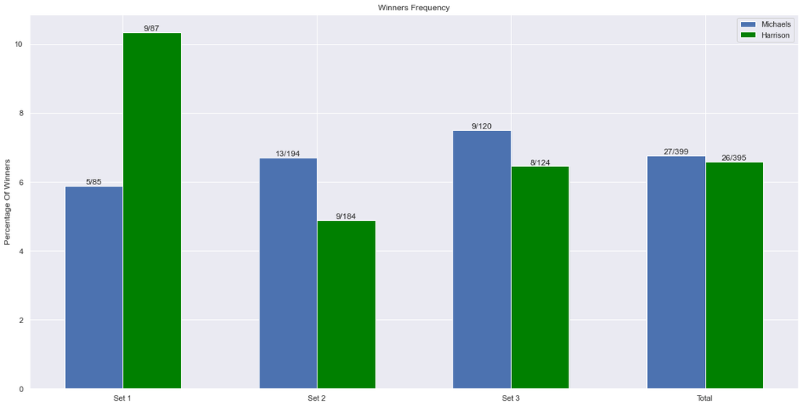

```python
df_winners_frequency = shot_frequency(df_winners_per_set, 'All Shots')
plot_frequency(df_winners_frequency, 'winners')
df_winners_frequency
```

## unforced errors/shot

*same as winners/shot but for unforced errors (shots containing ue)*

|  |  | Set 1 | Set 2 | Set 3 | Total |
| --- | --- | --- | --- | --- | --- |
| Michaels | Fraction | 11/85 | 12/194 | 9/120 | 32/399 |
|  | Percentage | 12.941176 | 6.185567 | 7.5 | 8.02005 |
| Harrison | Fraction | 9/87 | 10/184 | 11/124 | 30/395 |
|  | Percentage | 10.344828 | 5.434783 | 8.870968 | 7.594937 |

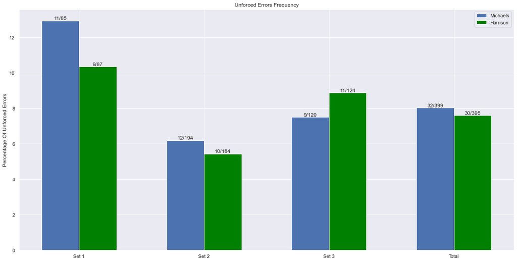

```python
df_ue_frequency = shot_frequency(df_unforced_errors_per_set, 'All Shots')
plot_frequency(df_ue_frequency, 'unforced errors')
df_ue_frequency
```

## forehand winners/shot

*forehand winners/total forehands (excluding v or o shots and excluding returns of serve)*

|  |  | Set 1 | Set 2 | Set 3 | Total |
| --- | --- | --- | --- | --- | --- |
| Michaels | Fraction | 4/47 | 9/113 | 4/66 | 17/226 |
|  | Percentage | 8.510638 | 7.964602 | 6.060606 | 7.522124 |
| Harrison | Fraction | 6/41 | 4/80 | 5/47 | 15/168 |
|  | Percentage | 14.634146 | 5.0 | 10.638298 | 8.928571 |

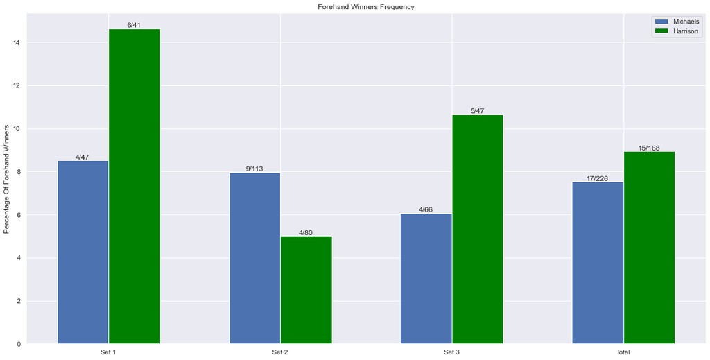

```python
df_forehand_winners_frequency = shot_frequency(df_winners_per_set, 'Total Forehand')
plot_frequency(df_forehand_winners_frequency, 'forehand winners')
df_forehand_winners_frequency
```

## backhand winners/shot

*same as forehand but for backhands*

|  |  | Set 1 | Set 2 | Set 3 | Total |
| --- | --- | --- | --- | --- | --- |
| Michaels | Fraction | 1/38 | 2/78 | 5/54 | 8/170 |
|  | Percentage | 2.631579 | 2.564103 | 9.259259 | 4.705882 |
| Harrison | Fraction | 3/46 | 4/102 | 3/77 | 10/225 |
|  | Percentage | 6.521739 | 3.921569 | 3.896104 | 4.444444 |

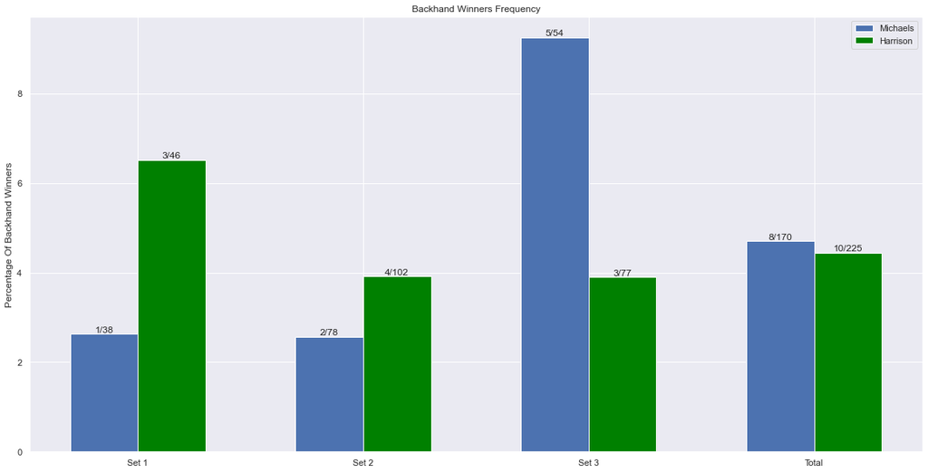

```python
df_backhand_winners_frequency = shot_frequency(df_winners_per_set, 'Total Backhand')
plot_frequency(df_backhand_winners_frequency, 'backhand winners')
df_backhand_winners_frequency
```

## forehand unforced errors/shot

*same process as for winners but with unforced errors.*

|  |  | Set 1 | Set 2 | Set 3 | Total |
| --- | --- | --- | --- | --- | --- |
| Michaels | Fraction | 4/47 | 6/113 | 7/66 | 17/226 |
|  | Percentage | 8.510638 | 5.309735 | 10.606061 | 7.522124 |
| Harrison | Fraction | 5/41 | 3/80 | 3/47 | 11/168 |
|  | Percentage | 12.195122 | 3.75 | 6.382979 | 6.547619 |

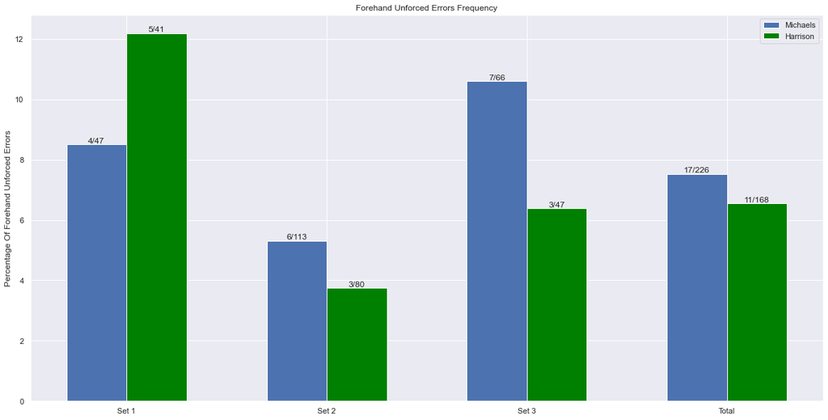

```python
df_forehand_ue_frequency = shot_frequency(df_unforced_errors_per_set, 'Total Forehand')
plot_frequency(df_forehand_ue_frequency, 'forehand unforced errors')
df_forehand_ue_frequency
```

## backhand unforced errors/shot

*same as forehand above but for backhand.*

|  |  | Set 1 | Set 2 | Set 3 | Total |
| --- | --- | --- | --- | --- | --- |
| Michaels | Fraction | 7/38 | 6/78 | 2/54 | 15/170 |
|  | Percentage | 18.421053 | 7.692308 | 3.703704 | 8.823529 |
| Harrison | Fraction | 4/46 | 7/102 | 8/77 | 19/225 |
|  | Percentage | 8.695652 | 6.862745 | 10.38961 | 8.444444 |

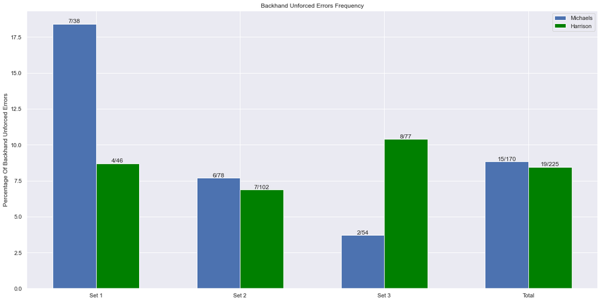

```python
df_backhand_ue_frequency = shot_frequency(df_unforced_errors_per_set, 'Total Backhand')
plot_frequency(df_backhand_ue_frequency, 'backhand unforced errors')
df_backhand_ue_frequency
```

## Break Points Saved

*break points are points where the returning player is one point away from winning the game (0-40, 15-40, 30-40, D-A or in the tiebreak anything where the returner has 6 or more points and at least one more point than the server ex. 3-6 would be a break point as would 7-8). This stat would look at all of these break points and take down the amount of points that qualify as break points won / total break point opportunities.*

```python
df_points_scores = pd.DataFrame(df.groupby(['serving','set','game','point_number'])['player1_game_score'].unique())
df_points_scores = df_points_scores.merge(pd.DataFrame(df.groupby(['serving','set','game','point_number'])['player2_game_score'].unique()), how='outer', left_index=True, right_index=True)
df_points_scores = df_points_scores.merge(pd.DataFrame(df.groupby(['serving','set','game','point_number'])['point_winner'].unique().rename('player3_game_score')), how='outer', left_index=True, right_index=True)

for i in range(1,4):
    df_points_scores['player'+str(i)+'_game_score'] = df_points_scores['player'+str(i)+'_game_score'].apply(lambda x: x[0])
df_points_scores.columns = ['Michaels_score','Harrison_score','point_winner']

break_point_list = []
for serving, receiving in [('Harrison','Michaels'),('Michaels','Harrison')]:
    serving_df = df_points_scores.loc[serving]
    break_point_list_serving = [
        s in ['40', 'A'] for s in serving_df[receiving + '_score']
    ]
    break_point_list += break_point_list_serving

df_points_scores = df_points_scores.merge(pd.DataFrame(break_point_list, columns=['break_point'], index=df_points_scores.index), how='outer', left_index=True, right_index=True)
```

```python
df_break_point = df_points_scores.query('break_point')
break_point_dict = {}
total_dict = {'Michaels':{'num':[],'total':[]},'Harrison':{'num':[],'total':[]}}
for set_num in range(1,4):
    break_point_list = []
    for serving, receiving in [('Harrison','Michaels'),('Michaels','Harrison')]:
        try:
            num = df_break_point.loc[serving, set_num]['point_winner'].value_counts()[receiving]
        except KeyError:
            num = 0
        try:
            total = len(df_break_point.loc[serving, set_num])
            break_point_fraction = str(num)+'/'+str(total)
            break_point_percentage = (num / total)*100
        except KeyError:
            break_point_fraction = '0/0'
            break_point_percentage = 0
        break_point_list.append(break_point_fraction)
        break_point_list.append(break_point_percentage)
        total_dict[serving]['num'].append(num)
        total_dict[serving]['total'].append(total)
    break_point_dict['Set '+str(set_num)] = break_point_list

total_list = []
for serving in ['Michaels','Harrison']:
    total_num = sum(total_dict[serving]['num'])
    total_total = sum(total_dict[serving]['total'])
    total_fraction = str(total_num)+'/'+str(total_total)
    total_percentage = (total_num/total_total)*100
    total_list.append(total_fraction)
    total_list.append(total_percentage)
break_point_dict['Total'] = total_list

df_break_point = pd.DataFrame(break_point_dict, index=pd.MultiIndex.from_tuples([('Michaels','Fraction'),
                                                                           ('Michaels','Percentage'),
                                                                           ('Harrison','Fraction'),
                                                                           ('Harrison','Percentage')]))
```

|  |  | Set 1 | Set 2 | Set 3 | Total |
| --- | --- | --- | --- | --- | --- |
| Michaels | Fraction | 0/2 | 0/0 | 3/5 | 3/6 |
|  | Percentage | 0.0 | 0 | 60.0 | 50.0 |
| Harrison | Fraction | 2/2 | 0/2 | 1/2 | 3/9 |
|  | Percentage | 100.0 | 0.0 | 50.0 | 33.333333 |

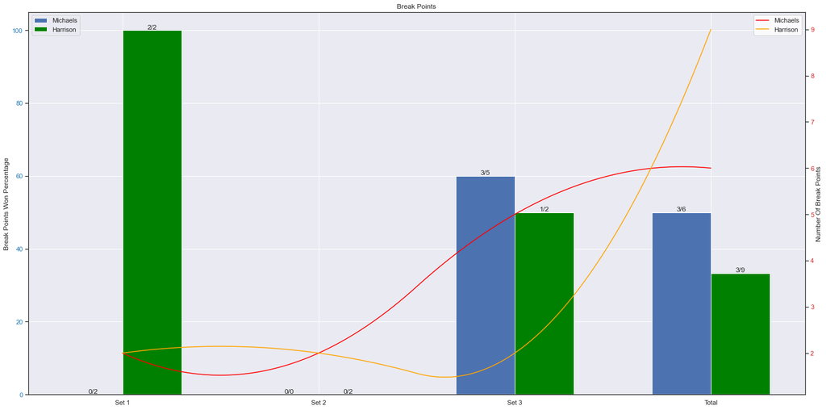

```python
fig, ax1 = plt.subplots(figsize=(20,10))

p1 = ax1.bar(np.arange(4)-0.3, df_break_point.loc['Michaels'].loc['Percentage'], 0.3, align='edge', label='Michaels')
p2 = ax1.bar(np.arange(4), df_break_point.loc['Harrison'].loc['Percentage'], 0.3, align='edge', label='Harrison', color='green')
plt.bar_label(p1,df_break_point.loc['Michaels','Fraction'])
plt.bar_label(p2,df_break_point.loc['Harrison','Fraction'])

ax1.set_ylabel('break points won percentage'.title())
ax1.tick_params(axis='y', labelcolor='tab:blue')
ax1.legend(loc='upper left')

sns.set_theme(style='white')
ax2 = ax1.twinx()

x=['Set 1','Set 2','Set 3','Total']
X_Y_Spline = make_interp_spline(np.arange(4), total_dict['Harrison']['total']+[6], 2)
X_ = np.linspace(np.arange(4).min(), np.arange(4).max(), 500)
Y_ = X_Y_Spline(X_)
ax2.plot(X_, Y_, color='red', label='Michaels')

X_Y_Spline = make_interp_spline(np.arange(4), total_dict['Michaels']['total']+[9], 2)
X_ = np.linspace(np.arange(4).min(), np.arange(4).max(), 500)
Y_ = X_Y_Spline(X_)
ax2.plot(X_, Y_, color='orange', label='Harrison')

plt.xticks(np.arange(4), x)
ax2.set_ylabel('number of break points'.title())
ax2.tick_params(axis='y', labelcolor='tab:red')
ax2.legend()

plt.title('Break Points'.title())
fig.tight_layout()

df_break_point
```

## Games facing break point

*how many different games the server faced a break point. Ex. the server faced a break point when serving at 0-1, then again in their next service game at 1-2, and finally another one in the second set at 5-4 for three different games with break points. This stat won't count the amount of break points within each game but just how many unique games there was a break point faced.*

```python
df_break_games = df_points_scores.groupby(['serving','set','game']).any().query('break_point').reset_index('game')
break_games_dict = {}
for set_num in range(1,4):
    break_games_num = []
    for serving in ['Michaels','Harrison']:
        try:
            break_games_num.append(len(df_break_games.loc[serving, set_num]))
        except KeyError:
            break_games_num.append(0)
    break_games_dict['Set '+str(set_num)] = break_games_num
df_break_games = pd.DataFrame(break_games_dict, index=['Michaels','Harrison'])
df_break_games = df_break_games.merge(df_break_games.sum(axis=1).rename('Total'), how='outer', left_index=True, right_index=True)
```

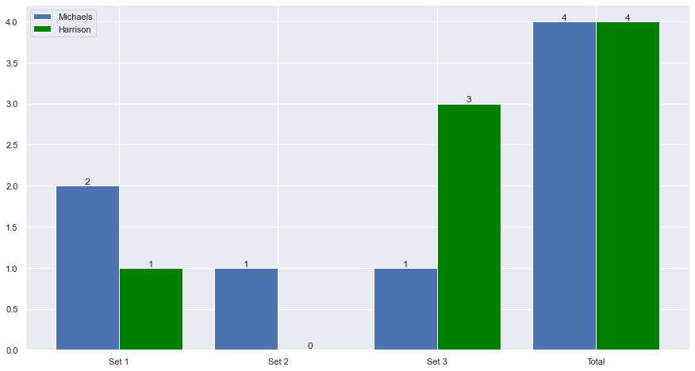

```python
sns.set_theme()
plt.figure(figsize=(15,8))
p1 = plt.bar(np.arange(4)-0.4, df_break_games.loc['Michaels'], 0.4, tick_label=df_break_games.columns, align='edge', label='Michaels')
plt.bar_label(p1, df_break_games.loc['Michaels'])
p2 = plt.bar(np.arange(4), df_break_games.loc['Harrison'], 0.4, tick_label=df_break_games.columns, align='edge', color='green', label='Harrison')
plt.bar_label(p2, df_break_games.loc['Harrison'])
plt.legend();
```

## Serve points won when return in play (total, vs 1st serve, vs 2nd serve):

*This stat filters for serves that went in and the first returning shot by the opponent that also went in. For this aces and faults will be filtered out for the server since it needs to be possible for the returner to get the ball back in play. So for this only FS and SS will be used for the server. For the returner only their first shot after a serve and only shots that went in will be used. First return shots with a ur, r, and ue will not be used.*

### Total rally won when serving

```python
df_serving_rally_won = pd.DataFrame(df.groupby(['serving','set','game','point_number','point_winner'])['action_number'].apply(len)).reset_index('point_winner').query('action_number > 1').drop('action_number', axis=1)
df_serving_rally_won = serve_points_won(df_serving_rally_won)
```

|  |  | Set 1 | Set 2 | Set 3 | Total |
| --- | --- | --- | --- | --- | --- |
| Michaels | Fraction | 11/21 | 31/46 | 15/26 | 57/93 |
|  | Percentage | 52.380952 | 67.391304 | 57.692308 | 61.290323 |
| Harrison | Fraction | 15/22 | 23/34 | 12/30 | 50/86 |
|  | Percentage | 68.181818 | 67.647059 | 40.0 | 58.139535 |

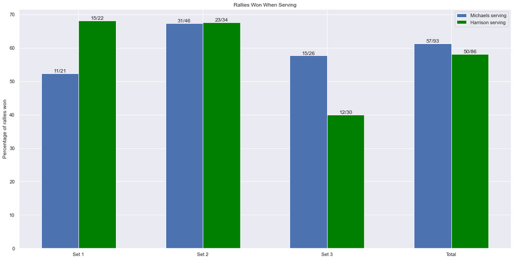

```python
plt.figure(figsize=(20,10))
p1 = plt.bar(np.arange(4)-0.3, df_serving_rally_won.loc['Michaels', 'Percentage'], 0.3, align='edge', label='Michaels serving')
p2 = plt.bar(np.arange(4), df_serving_rally_won.loc['Harrison', 'Percentage'], 0.3, align='edge', label='Harrison serving', color='green')

plt.bar_label(p1, df_serving_rally_won.loc['Michaels','Fraction'])
plt.bar_label(p2, df_serving_rally_won.loc['Harrison','Fraction'])

plt.xticks(np.arange(4), df_serving_rally_won.columns)
plt.ylabel('Percentage of rallies won')
plt.title('Rallies won when serving'.title())
plt.legend();

df_serving_rally_won
```

### First Serve rally won when serving

```python
df_fs_rally_won = pd.DataFrame(df.groupby(['serving','set','game','point_number','point_winner'])['action_number'].count())
df_fs_rally_won = df_fs_rally_won.merge(df.groupby(['serving','set','game','point_number','point_winner'])['action'].apply(list), how='outer',left_index=True,right_index=True)
df_fs_rally_won = df_fs_rally_won.query('action_number > 1')
df_fs_rally_won = df_fs_rally_won[df_fs_rally_won['action'].apply(lambda x: 'FS' in x)]
df_fs_rally_won = serve_points_won(df_fs_rally_won.reset_index('point_winner').drop(['action_number','action'], axis=1))
```

|  |  | Set 1 | Set 2 | Set 3 | Total |
| --- | --- | --- | --- | --- | --- |
| Michaels | Fraction | 2/8 | 11/20 | 9/16 | 22/44 |
|  | Percentage | 25.0 | 55.0 | 56.25 | 50.0 |
| Harrison | Fraction | 7/12 | 10/13 | 6/14 | 23/39 |
|  | Percentage | 58.333333 | 76.923077 | 42.857143 | 58.974359 |

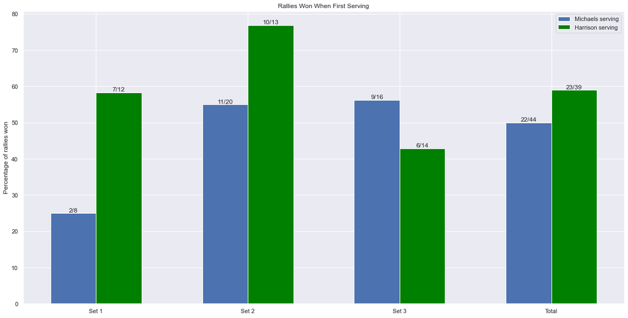

```python
plt.figure(figsize=(20,10))
p1 = plt.bar(np.arange(4)-0.3, df_fs_rally_won.loc['Michaels', 'Percentage'], 0.3, align='edge', label='Michaels serving')
p2 = plt.bar(np.arange(4), df_fs_rally_won.loc['Harrison', 'Percentage'], 0.3, align='edge', label='Harrison serving', color='green')

plt.bar_label(p1, df_fs_rally_won.loc['Michaels','Fraction'])
plt.bar_label(p2, df_fs_rally_won.loc['Harrison','Fraction'])

plt.xticks(np.arange(4), df_fs_rally_won.columns)
plt.ylabel('Percentage of rallies won')
plt.title('Rallies won when first serving'.title())
plt.legend();

df_fs_rally_won
```

### Second Serve rally won when serving

```python
df_ss_rally_won = pd.DataFrame(df.groupby(['serving','set','game','point_number','point_winner'])['action_number'].count())
df_ss_rally_won = df_ss_rally_won.merge(df.groupby(['serving','set','game','point_number','point_winner'])['action'].apply(list), how='outer',left_index=True,right_index=True)
df_ss_rally_won = df_ss_rally_won.query('action_number > 1')
df_ss_rally_won = df_ss_rally_won[df_ss_rally_won['action'].apply(lambda x: 'SS' in x)]
df_ss_rally_won = serve_points_won(df_ss_rally_won.reset_index('point_winner').drop(['action_number','action'], axis=1))
```

|  |  | Set 1 | Set 2 | Set 3 | Total |
| --- | --- | --- | --- | --- | --- |
| Michaels | Fraction | 5/8 | 10/15 | 1/5 | 16/28 |
|  | Percentage | 62.5 | 66.666667 | 20.0 | 57.142857 |
| Harrison | Fraction | 4/6 | 4/9 | 3/11 | 11/26 |
|  | Percentage | 66.666667 | 44.444444 | 27.272727 | 42.307692 |

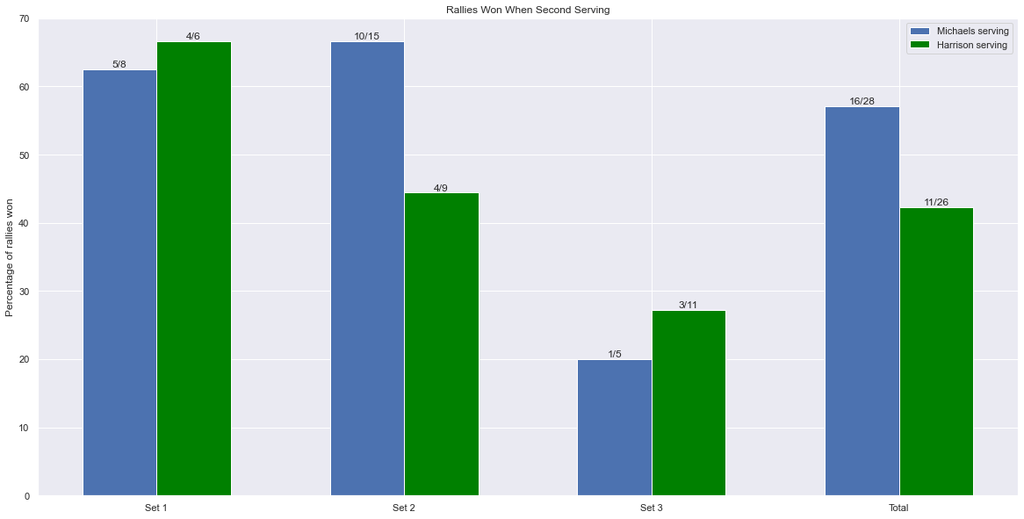

```python
plt.figure(figsize=(20,10))
p1 = plt.bar(np.arange(4)-0.3, df_ss_rally_won.loc['Michaels', 'Percentage'], 0.3, align='edge', label='Michaels serving')
p2 = plt.bar(np.arange(4), df_ss_rally_won.loc['Harrison', 'Percentage'], 0.3, align='edge', label='Harrison serving', color='green')

plt.bar_label(p1, df_ss_rally_won.loc['Michaels','Fraction'])
plt.bar_label(p2, df_ss_rally_won.loc['Harrison','Fraction'])

plt.xticks(np.arange(4), df_ss_rally_won.columns)
plt.ylabel('Percentage of rallies won')
plt.title('Rallies won when second serving'.title())
plt.legend();

df_ss_rally_won
```